# Week 2-3: home assignment

Manuel Trombetta

2026-01-28

```r
library(tidyverse)
library(ggplot2)
library(effsize)
library(car)
library(broom)
```

```r
# load data:
nettle <- read_csv("https://osf.io/download/ptq7u")
head(nettle)
```

```
## # A tibble: 6 × 5
##   Country    Population  Area   MGS Langs
##   <chr>           <dbl> <dbl> <dbl> <dbl>
## 1 Algeria          4.41  6.38  6.6     18
## 2 Angola           4.01  6.1   6.22    42
## 3 Australia        4.24  6.89  6      234
## 4 Bangladesh       5.07  5.16  7.4     37
## 5 Benin            3.69  5.05  7.14    52
## 6 Bolivia          3.88  6.04  6.92    38
```

## Task 1

In this section we will look at “Langs” distribution by plotting it.

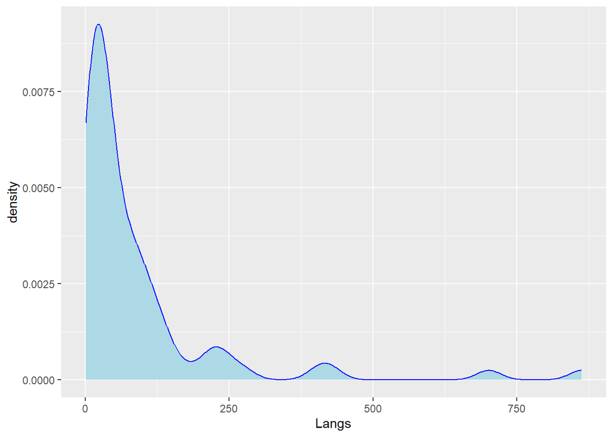

```r
nettle %>%
  ggplot(aes(Langs)) +
  geom_density(color="blue", fill = "lightblue")
```

By looking at the plot, we see that “Langs” has a few very high values and many small ones. To avoid giving too much weight to a small number of observations, we apply a log transformation, which compresses the data and makes the distribution more symmetric.

```r
nettle <- nettle %>%
  mutate(Log_langs = log10(Langs))

# let's check
head(nettle)
```

```
## # A tibble: 6 × 6
##   Country    Population  Area   MGS Langs Log_langs
##   <chr>           <dbl> <dbl> <dbl> <dbl>     <dbl>
## 1 Algeria          4.41  6.38  6.6     18      1.26
## 2 Angola           4.01  6.1   6.22    42      1.62
## 3 Australia        4.24  6.89  6      234      2.37
## 4 Bangladesh       5.07  5.16  7.4     37      1.57
## 5 Benin            3.69  5.05  7.14    52      1.72
## 6 Bolivia          3.88  6.04  6.92    38      1.58
```

## Task 2

Now, we are interested in whether linguistic diversity within a country depends on population size, geographic area, and climatic conditions. For this reason, Mean Growing Season is not treated as a continuous variable, since we are not interested in small linear variations in the number of growing days, but rather in differences between broader climatic regimes. By grouping Mean Growing Season into categories, we avoid assuming a linear effect and focus on comparing countries with substantially different environmental conditions.

```r
nettle <-
  mutate(nettle, MGS_cat = factor(ifelse(MGS < 6, 'non-fertile', 'fertile')))

# explore the data
head(nettle)
```

```
## # A tibble: 6 × 7
##   Country    Population  Area   MGS Langs Log_langs MGS_cat
##   <chr>           <dbl> <dbl> <dbl> <dbl>     <dbl> <fct>
## 1 Algeria          4.41  6.38  6.6     18      1.26 fertile
## 2 Angola           4.01  6.1   6.22    42      1.62 fertile
## 3 Australia        4.24  6.89  6      234      2.37 fertile
## 4 Bangladesh       5.07  5.16  7.4     37      1.57 fertile
## 5 Benin            3.69  5.05  7.14    52      1.72 fertile
## 6 Bolivia          3.88  6.04  6.92    38      1.58 fertile
```

Now it is time to create the multiple linear regression model. Then, we plot residuals against fitted values as a diagnostic check of the linear model.

```r
nettle_lm <- lm(Log_langs ~ Population + Area + MGS_cat, data=nettle)
summary(nettle_lm)
```

```
##
## Call:
## lm(formula = Log_langs ~ Population + Area + MGS_cat, data = nettle)
##
## Residuals:
##      Min       1Q   Median       3Q      Max
## -1.55900 -0.27068 -0.01724  0.28692  1.31292
##
## Coefficients:
##                    Estimate Std. Error t value Pr(>|t|)
## (Intercept)         -0.7699     0.5897  -1.306   0.1959
## Population           0.2386     0.1041   2.293   0.0249 *
## Area                 0.2713     0.1320   2.056   0.0435 *
## MGS_catnon-fertile  -0.3174     0.1307  -2.428   0.0177 *
## ---
## Signif. codes:  0 '***' 0.001 '**' 0.01 '*' 0.05 '.' 0.1 ' ' 1
##
## Residual standard error: 0.4806 on 70 degrees of freedom
## Multiple R-squared:  0.2763, Adjusted R-squared:  0.2453
## F-statistic: 8.909 on 3 and 70 DF,  p-value: 4.456e-05
```

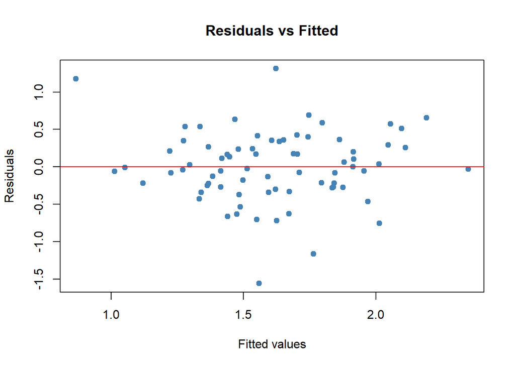

```r
# plot residuals vs fitted values
plot(
  fitted(nettle_lm),
  residuals(nettle_lm),
  col = "steelblue",
  pch = 19,  # pch specifies the point symbol used in the plot (solid circles)
  xlab = "Fitted values",
  ylab = "Residuals",
  main = "Residuals vs Fitted"
)
abline(h = 0, col = "red")
```

We fitted a linear regression model with log-transformed linguistic diversity (Log_langs) as the response variable and population size, geographic area, and mean growing season category as predictors. The model explains a moderate proportion of the variance (R² = 0.28, adjusted R² = 0.25). Population (β = 0.24) and area (β = 0.27) show a positive association with linguistic diversity, while countries classified as non-fertile display lower linguistic diversity compared to fertile ones (β = −0.32).

## Task 3

Now it is time to check whether the assumptions of the model are satisfied. The assumptions are:

- The relationship between the variables is/seems linear
- the datapoints are independed of one another
- The variance of the residuals is roughly constant
- The residuals are roughly normally distributed

As regards to the first one, linearity was assessed by inspecting the residuals versus fitted values plot. The absence of systematic patterns suggests that the relationship between predictors and response is reasonably linear.

Independence of observations is assumed, as each data point represents a different country. In addition, multicollinearity among predictors was assessed and does not appear to be problematic, suggesting that the estimated coefficients are stable and interpretable.

```r
# vif to undestand if there is collinearity among data:
vif(nettle_lm)
```

```
## Population       Area    MGS_cat
##   1.544890   1.683960   1.143544
```

Values below 2 mean that there is no collinearity among data. If the value had been around 10, it would have been a problem.

as regards to the third point, homoscedasticity was assessed by inspecting the residuals versus fitted values plot. The spread of the residuals appears roughly constant across fitted values, suggesting no strong evidence of heteroscedasticity.

Residual normality was assessed visually using a histogram of the residuals, which suggests that the residuals are approximately normally distributed.

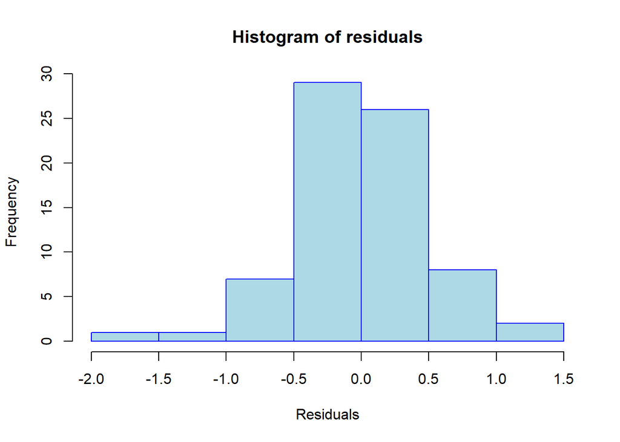

```r
hist(
  residuals(nettle_lm),
  col = "lightblue",
  border = "blue",
  main = "Histogram of residuals",
  xlab = "Residuals"
)
```

## Task 4

Next step is to draw a plot with the confidence intervals.

The first thing to do is to standardize ‘Log_langs’ and ‘Area’ variables. It is necessary because the variables are on different scales, they are standardized using scale(), which centers each variable to mean 0 and rescales it to unit variance, making coefficients and confidence intervals comparable.

```r
nettle_2 <- nettle %>%
  mutate(Log_langs = scale(Log_langs),
         Area = scale(Area))

head(nettle)
```

```
## # A tibble: 6 × 7
##   Country    Population  Area   MGS Langs Log_langs MGS_cat
##   <chr>           <dbl> <dbl> <dbl> <dbl>     <dbl> <fct>
## 1 Algeria          4.41  6.38  6.6     18      1.26 fertile
## 2 Angola           4.01  6.1   6.22    42      1.62 fertile
## 3 Australia        4.24  6.89  6      234      2.37 fertile
## 4 Bangladesh       5.07  5.16  7.4     37      1.57 fertile
## 5 Benin            3.69  5.05  7.14    52      1.72 fertile
## 6 Bolivia          3.88  6.04  6.92    38      1.58 fertile
```

```r
head(nettle_2)
```

```
## # A tibble: 6 × 7
##   Country    Population Area[,1]   MGS Langs Log_langs[,1] MGS_cat
##   <chr>           <dbl>    <dbl> <dbl> <dbl>         <dbl> <fct>
## 1 Algeria          4.41    1.38   6.6     18       -0.645  fertile
## 2 Angola           4.01    0.872  6.22    42        0.0199 fertile
## 3 Australia        4.24    2.30   6      234        1.37   fertile
## 4 Bangladesh       5.07   -0.828  7.4     37       -0.0796 fertile
## 5 Benin            3.69   -1.03   7.14    52        0.188  fertile
## 6 Bolivia          3.88    0.764  6.92    38       -0.0587 fertile
```

Now we have to recreate the linear model used earlier with new standardized variables

```r
nettle_lm2 <- lm(Log_langs ~ Population + Area + MGS_cat, data=nettle_2)
summary(nettle_lm2)
```

```
##
## Call:
## lm(formula = Log_langs ~ Population + Area + MGS_cat, data = nettle_2)
##
## Residuals:
##      Min       1Q   Median       3Q      Max
## -2.81823 -0.48930 -0.03117  0.51866  2.37339
##
## Coefficients:
##                    Estimate Std. Error t value Pr(>|t|)
## (Intercept)         -1.5509     0.7757  -1.999   0.0494 *
## Population           0.4313     0.1881   2.293   0.0249 *
## Area                 0.2712     0.1319   2.056   0.0435 *
## MGS_catnon-fertile  -0.5738     0.2363  -2.428   0.0177 *
## ---
## Signif. codes:  0 '***' 0.001 '**' 0.01 '*' 0.05 '.' 0.1 ' ' 1
##
## Residual standard error: 0.8687 on 70 degrees of freedom
## Multiple R-squared:  0.2763, Adjusted R-squared:  0.2453
## F-statistic: 8.909 on 3 and 70 DF,  p-value: 4.456e-05
```

After that, we tidy the coefficient summary and add the lower and upper limits of the 95% confidence intervals.

```r
mycoefs <- tidy(nettle_lm2, conf.int = TRUE)
head(mycoefs)
```

```
## # A tibble: 4 × 7
##   term               estimate std.error statistic p.value conf.low conf.high
##   <chr>                 <dbl>     <dbl>     <dbl>   <dbl>    <dbl>     <dbl>
## 1 (Intercept)          -1.55      0.776     -2.00  0.0494 -3.10     -0.00384
## 2 Population            0.431     0.188      2.29  0.0249  0.0561    0.806
## 3 Area                  0.271     0.132      2.06  0.0435  0.00809   0.534
## 4 MGS_catnon-fertile   -0.574     0.236     -2.43  0.0177 -1.05     -0.103
```

Next, we plot the model coefficients together with their 95% confidence intervals.

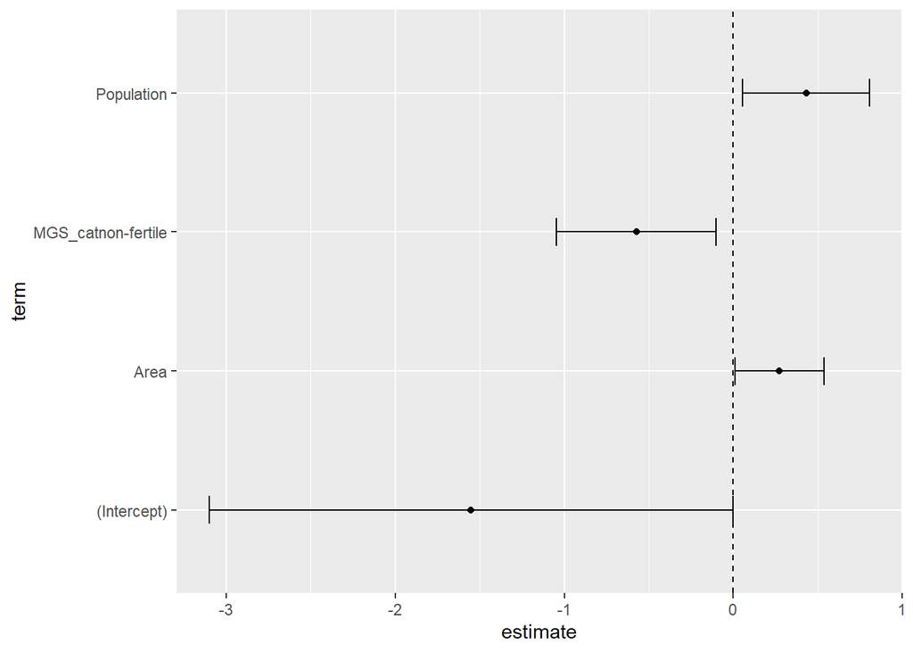

```r
mycoefs %>%
  ggplot(aes(x = term, y = estimate)) +
  geom_point() +
  geom_errorbar(aes(ymin = conf.low,
                    ymax = conf.high),
                width = 0.2) +
  geom_hline(yintercept = 0, linetype = 2) +
  coord_flip()
```